```python
import os
import pandas as pd
import numpy as np
import seaborn as sns
import matplotlib.pyplot as plt
from IPython.display import Image
%matplotlib inline
```

```python
os.chdir('E:\个人\DataWhale\数据分析\动手学数据分析-组队学习版\第三章项目集合')
plt.rcParams['font.sans-serif'] = ['SimHei']  # 用来正常显示中文标签
plt.rcParams['axes.unicode_minus'] = False  # 用来正常显示负号
plt.rcParams['figure.figsize'] = (10, 6)  # 设置输出图片大小
```

```python
# 读取训练数集
train = pd.read_csv('train.csv')
train.shape
```

```
(891, 12)
```

```python
train.head(5).append(train.tail(5))
```

|  | PassengerId | Survived | Pclass | Name | Sex | Age | SibSp | Parch | Ticket | Fare | Cabin | Embarked |
| --- | --- | --- | --- | --- | --- | --- | --- | --- | --- | --- | --- | --- |
| 0 | 1 | 0 | 3 | Braund, Mr. Owen Harris | male | 22.0 | 1 | 0 | A/5 21171 | 7.2500 | NaN | S |
| 1 | 2 | 1 | 1 | Cumings, Mrs. John Bradley (Florence Briggs Th... | female | 38.0 | 1 | 0 | PC 17599 | 71.2833 | C85 | C |
| 2 | 3 | 1 | 3 | Heikkinen, Miss. Laina | female | 26.0 | 0 | 0 | STON/O2. 3101282 | 7.9250 | NaN | S |
| 3 | 4 | 1 | 1 | Futrelle, Mrs. Jacques Heath (Lily May Peel) | female | 35.0 | 1 | 0 | 113803 | 53.1000 | C123 | S |
| 4 | 5 | 0 | 3 | Allen, Mr. William Henry | male | 35.0 | 0 | 0 | 373450 | 8.0500 | NaN | S |
| 886 | 887 | 0 | 2 | Montvila, Rev. Juozas | male | 27.0 | 0 | 0 | 211536 | 13.0000 | NaN | S |
| 887 | 888 | 1 | 1 | Graham, Miss. Margaret Edith | female | 19.0 | 0 | 0 | 112053 | 30.0000 | B42 | S |
| 888 | 889 | 0 | 3 | Johnston, Miss. Catherine Helen "Carrie" | female | NaN | 1 | 2 | W./C. 6607 | 23.4500 | NaN | S |
| 889 | 890 | 1 | 1 | Behr, Mr. Karl Howell | male | 26.0 | 0 | 0 | 111369 | 30.0000 | C148 | C |
| 890 | 891 | 0 | 3 | Dooley, Mr. Patrick | male | 32.0 | 0 | 0 | 370376 | 7.7500 | NaN | Q |

```python
 # sns.pairplot(train,hue='Survived')
```

## 1 特征工程

- 任务一：缺失值填充
  - 对分类变量缺失值：填充某个缺失值字符(NA)、用最多类别的进行填充
  - 对连续变量缺失值：填充均值、中位数、众数

```python
train.info()
```

```
<class 'pandas.core.frame.DataFrame'>
RangeIndex: 891 entries, 0 to 890
Data columns (total 12 columns):
 #   Column       Non-Null Count  Dtype
---  ------       --------------  -----
 0   PassengerId  891 non-null    int64
 1   Survived     891 non-null    int64
 2   Pclass       891 non-null    int64
 3   Name         891 non-null    object
 4   Sex          891 non-null    object
 5   Age          714 non-null    float64
 6   SibSp        891 non-null    int64
 7   Parch        891 non-null    int64
 8   Ticket       891 non-null    object
 9   Fare         891 non-null    float64
 10  Cabin        204 non-null    object
 11  Embarked     889 non-null    object
dtypes: float64(2), int64(5), object(5)
memory usage: 83.7+ KB
```

```python
train['Age'] = train['Age'].fillna(train['Age'].mean())
```

```python
# 对分类变量进行填充
train['Cabin'] = train['Cabin'].fillna('NA')
train['Embarked'] = train['Embarked'].fillna('S')
```

```python
# 检查缺失值比例
print(type(train.isnull()))
train.isnull().mean().sort_values(ascending=False)
```

```
<class 'pandas.core.frame.DataFrame'>
```

```
Embarked       0.0
Cabin          0.0
Fare           0.0
Ticket         0.0
Parch          0.0
SibSp          0.0
Age            0.0
Sex            0.0
Name           0.0
Pclass         0.0
Survived       0.0
PassengerId    0.0
dtype: float64
```

## 2 对变量进行编码分类

```python
# 取出所有的输入特征
data=train[['Pclass','Sex','Age','SibSp','Parch','Fare', 'Embarked']]
data.head(3).append(data.tail(3))
```

|  | Pclass | Sex | Age | SibSp | Parch | Fare | Embarked |
| --- | --- | --- | --- | --- | --- | --- | --- |
| 0 | 3 | male | 22.000000 | 1 | 0 | 7.2500 | S |
| 1 | 1 | female | 38.000000 | 1 | 0 | 71.2833 | C |
| 2 | 3 | female | 26.000000 | 0 | 0 | 7.9250 | S |
| 888 | 3 | female | 29.699118 | 1 | 2 | 23.4500 | S |
| 889 | 1 | male | 26.000000 | 0 | 0 | 30.0000 | C |
| 890 | 3 | male | 32.000000 | 0 | 0 | 7.7500 | Q |

```python
# 进行虚拟变量转换
data = pd.get_dummies(data)
data.head(3).append(data.tail(3))
```

|  | Pclass | Age | SibSp | Parch | Fare | Sex_female | Sex_male | Embarked_C | Embarked_Q | Embarked_S |
| --- | --- | --- | --- | --- | --- | --- | --- | --- | --- | --- |
| 0 | 3 | 22.000000 | 1 | 0 | 7.2500 | 0 | 1 | 0 | 0 | 1 |
| 1 | 1 | 38.000000 | 1 | 0 | 71.2833 | 1 | 0 | 1 | 0 | 0 |
| 2 | 3 | 26.000000 | 0 | 0 | 7.9250 | 1 | 0 | 0 | 0 | 1 |
| 888 | 3 | 29.699118 | 1 | 2 | 23.4500 | 1 | 0 | 0 | 0 | 1 |
| 889 | 1 | 26.000000 | 0 | 0 | 30.0000 | 0 | 1 | 1 | 0 | 0 |
| 890 | 3 | 32.000000 | 0 | 0 | 7.7500 | 0 | 1 | 0 | 1 | 0 |

## 3 模型搭建

- 处理完前面的数据我们就得到建模数据，下一步是选择合适模型
- 在进行模型选择之前我们需要先知道数据集最终是进行监督学习还是无监督学习
- 除了根据我们任务来选择模型外，还可以根据数据样本量以及特征的稀疏性来决定
- 刚开始我们总是先尝试使用一个基本的模型来作为其baseline，进而再训练其他模型做对比，最终选择泛化能力或性能比较好的模型

### 3.1 切割训练集与测试集

```python
from sklearn.model_selection import train_test_split
```

```python
# 一般先取出X和y后再切割，有些情况会使用到未切割的，这时候X和y就可以用
X = data
y = train['Survived']
```

```python
# 对数据集进行切割
X_train, X_test, y_train, y_test = train_test_split(X, y, stratify=y, random_state=0)
```

```python
# 查看数据形状
X_train.shape, X_test.shape
```

```
((668, 10), (223, 10))
```

### 3.2 模型选择

```python
from sklearn.linear_model import LogisticRegression
from sklearn.ensemble import RandomForestClassifier
```

```python
# 默认参数逻辑回归模型
lr = LogisticRegression(max_iter=3000)
lr.fit(X_train, y_train)
```

```
LogisticRegression(max_iter=3000)
```

```python
# 查看训练集和测试集score值
print("Training set score: {:.2f}".format(lr.score(X_train, y_train)))
print("Testing set score: {:.2f}".format(lr.score(X_test, y_test)))
```

```
Training set score: 0.80
Testing set score: 0.79
```

```python
# 默认参数的随机森林分类模型
rfc = RandomForestClassifier()
rfc.fit(X_train, y_train)
```

```
RandomForestClassifier()
```

```python
print("Training set score: {:.2f}".format(rfc.score(X_train, y_train)))
print("Testing set score: {:.2f}".format(rfc.score(X_test, y_test)))
```

```
Training set score: 0.99
Testing set score: 0.82
```

```python
# 预测标签
pred = lr.predict(X_train)
pred[:10]
```

```
array([0, 1, 1, 1, 0, 0, 1, 0, 1, 1], dtype=int64)
```

```python
# 预测标签概率
pred_proba = lr.predict_proba(X_train)
pred_proba[:10]
```

```
array([[0.6001464 , 0.3998536 ],
       [0.12789276, 0.87210724],
       [0.46653417, 0.53346583],
       [0.18617982, 0.81382018],
       [0.86643817, 0.13356183],
       [0.91115021, 0.08884979],
       [0.11983548, 0.88016452],
       [0.90990906, 0.09009094],
       [0.04887101, 0.95112899],
       [0.13218886, 0.86781114]])
```

### 3.3 模型评估

模型评估是为了知道模型的泛化能力。

- 交叉验证（cross-validation）是一种评估泛化性能的统计学方法，它比单次划分训练集和测试集的方法更加稳定、全面。
- 在交叉验证中，数据被多次划分，并且需要训练多个模型。
- 最常用的交叉验证是 k 折交叉验证（k-fold cross-validation），其中 k 是由用户指定的数字，通常取 5 或 10。
- 准确率（precision）度量的是被预测为正例的样本中有多少是真正的正例
- 召回率（recall）度量的是正类样本中有多少被预测为正类
- f-分数是准确率与召回率的调和平均

K交叉验证

```python
from sklearn.model_selection import cross_val_score
```

```python
lr = LogisticRegression(C=100,max_iter=3000)
scores = cross_val_score(lr, X_train, y_train, cv=10)
```

```python
# k折交叉验证分数
scores
```

```
array([0.8358209 , 0.7761194 , 0.82089552, 0.79104478, 0.85074627,
       0.86567164, 0.73134328, 0.86567164, 0.75757576, 0.71212121])
```

```python
# 平均交叉验证分数
print("Average cross-validation score: {:.2f}".format(scores.mean()))
```

```
Average cross-validation score: 0.80
```

混淆矩阵 计算二分类问题的混淆矩阵 计算精确率、召回率以及f-分数

```python
from sklearn.metrics import confusion_matrix
```

```python
# 训练模型
lr = LogisticRegression(C=100,max_iter=3000)
lr.fit(X_train, y_train)
```

```
LogisticRegression(C=100, max_iter=3000)
```

```python
# 模型预测结果
pred = lr.predict(X_train)
```

```python
# 混淆矩阵
confusion_matrix(y_train, pred)
```

```
array([[350,  62],
       [ 71, 185]], dtype=int64)
```

```python
from sklearn.metrics import classification_report
```

```python
# 精确率、召回率以及f1-score
print(classification_report(y_train, pred))
```

```
              precision    recall  f1-score   support

           0       0.83      0.85      0.84       412
           1       0.75      0.72      0.74       256

    accuracy                           0.80       668
   macro avg       0.79      0.79      0.79       668
weighted avg       0.80      0.80      0.80       668
```

ROC曲线

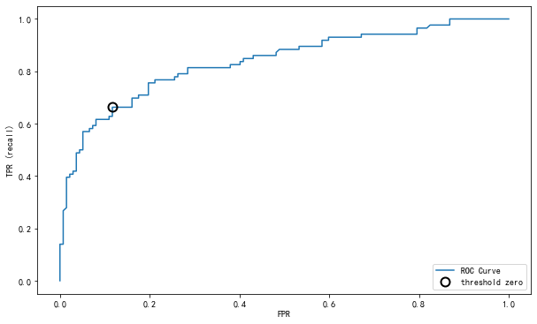

```python
from sklearn.metrics import roc_curve
fpr, tpr, thresholds = roc_curve(y_test, lr.decision_function(X_test))
plt.plot(fpr, tpr, label="ROC Curve")
plt.xlabel("FPR")
plt.ylabel("TPR (recall)")
# 找到最接近于0的阈值
close_zero = np.argmin(np.abs(thresholds))
plt.plot(fpr[close_zero], tpr[close_zero], 'o', markersize=10, label="threshold zero", fillstyle="none", c='k', mew=2)
plt.legend(loc=4)
```